# Pratical Machine Learning - Course Project

Vitor Zamprogno amancio Pereira

4/1/2018

## Summary

Using devices such as Jawbone Up, Nike FuelBand, and Fitbit it is now possible to collect a large amount of data about personal activity relatively inexpensively. These type of devices are part of the quantified self movement – a group of enthusiasts who take measurements about themselves regularly to improve their health, to find patterns in their behavior, or because they are tech geeks. One thing that people regularly do is quantify how much of a particular activity they do, but they rarely quantify how well they do it. In this project, your goal will be to use data from accelerometers on the belt, forearm, arm, and dumbell of 6 participants.

## The HAR Dataset

| classe | description |
| --- | --- |
| A | exactly according to the specification |
| B | throwing the elbows to the front |
| C | lifting the dumbbell only halfway |
| D | lowering the dumbbell only halfway |
| E | throwing the hips to the front |

For more information see: Ugulino, W.; Cardador, D.; Vega, K.; Velloso, E.; Milidiu, R.; Fuks, H. Wearable Computing: Accelerometers’ Data Classification of Body Postures and Movements. Proceedings of 21st Brazilian Symposium on Artificial Intelligence. Advances in Artificial Intelligence - SBIA 2012. In: Lecture Notes in Computer Science. , pp. 52-61. Curitiba, PR: Springer Berlin / Heidelberg, 2012. ISBN 978-3-642-34458-9. DOI: 10.1007/978-3-642-34459-6_6.

The project data are available here:

- Trainig: https://d396qusza40orc.cloudfront.net/predmachlearn/pml-training.csv
- Test: https://d396qusza40orc.cloudfront.net/predmachlearn/pml-testing.csv

## Importing the data

```r
setwd("~/Documents/DataAnalyst/CouseraCourse/8- Pratical Machine Learninig/project")
url="https://d396qusza40orc.cloudfront.net/predmachlearn/pml-training.csv"
fileName=basename(url)
if (!file.exists(fileName))
{
      download.file(url.training,basename(url.training),method="curl")
}
harDataset=read.csv(fileName)
#
url="https://d396qusza40orc.cloudfront.net/predmachlearn/pml-testing.csv"
fileName=basename(url)
if (!file.exists(fileName))
{
    download.file(url.testing,basename(url.testing),method="curl")
}
testing=read.csv(fileName)
```

## Exploratory Analysis and Variable selection

##### Looking at the file structure

```r
str(harDataset)
```

```
## 'data.frame':    19622 obs. of  160 variables:
##  $ X                       : int  1 2 3 4 5 6 7 8 9 10 ...
##  $ user_name               : Factor w/ 6 levels "adelmo","carlitos",..: 2 2 2 2 2 2 2 2 2 2 ...
##  $ raw_timestamp_part_1    : int  1323084231 1323084231 1323084231 1323084232 1323084232 1323084232 1323084232 1323084232 1323084232 1323084232 ...
##  $ raw_timestamp_part_2    : int  788290 808298 820366 120339 196328 304277 368296 440390 484323 484434 ...
##  $ cvtd_timestamp          : Factor w/ 20 levels "02/12/2011 13:32",..: 9 9 9 9 9 9 9 9 9 9 ...
##  $ new_window              : Factor w/ 2 levels "no","yes": 1 1 1 1 1 1 1 1 1 1 ...
##  $ num_window              : int  11 11 11 12 12 12 12 12 12 12 ...
##  $ roll_belt               : num  1.41 1.41 1.42 1.48 1.48 1.45 1.42 1.42 1.43 1.45 ...
##  $ pitch_belt              : num  8.07 8.07 8.07 8.05 8.07 8.06 8.09 8.13 8.16 8.17 ...
##  $ yaw_belt                : num  -94.4 -94.4 -94.4 -94.4 -94.4 -94.4 -94.4 -94.4 -94.4 -94.4 ...
##  $ total_accel_belt        : int  3 3 3 3 3 3 3 3 3 3 ...
##  $ kurtosis_roll_belt      : Factor w/ 397 levels "","-0.016850",..: 1 1 1 1 1 1 1 1 1 1 ...
##  $ kurtosis_picth_belt     : Factor w/ 317 levels "","-0.021887",..: 1 1 1 1 1 1 1 1 1 1 ...
##  $ kurtosis_yaw_belt       : Factor w/ 2 levels "","#DIV/0!": 1 1 1 1 1 1 1 1 1 1 ...
```

[output cut: 86 more lines]

The first 7 variables are identification information and time of measurements and do not directly influence the variable to be predicted (classe), and thus can be removed.

```r
wHarDataset = harDataset[,-1:-7]
dim(wHarDataset)
```

```
## [1] 19622   153
```

There are variables with NA and “”

##### Let’s replace the values “” by NA

```r
wHarDataset[wHarDataset==""]=NA
```

##### Counting the NA values per column

```r
NAAmountPerColumn=sapply(wHarDataset,function(x) { sum(is.na(x)) })
table(NAAmountPerColumn)
```

```
## NAAmountPerColumn
##     0 19216
##    53   100
```

```r
print(paste(round((((nrow(wHarDataset) - 19216))/nrow(wHarDataset)) * 100,digits=2),"% filled",sep=""))
```

```
## [1] "2.07% filled"
```

A very small percentage of valid information and so we can remove these columns

##### Removing columns with very few data

```r
wHarDataset =  wHarDataset[,NAAmountPerColumn==0]
dim(wHarDataset)
```

```
## [1] 19622    53
```

#### Analyzing the correlation between the variables

##### Identifying the highest correlations

```r
# Calculating the correlation matrix
mCorrelation <- cor(wHarDataset[sapply(wHarDataset,function(x) {!is.factor(x)})])
# Identifying variables with high correlation  (>0.75)
hCorrVars <- findCorrelation(mCorrelation, cutoff=0.5,names=TRUE, exact=TRUE)
print(hCorrVars)
```

```
##  [1] "accel_belt_z"         "roll_belt"            "accel_belt_y"
##  [4] "accel_arm_y"          "total_accel_belt"     "yaw_belt"
##  [7] "accel_dumbbell_z"     "accel_belt_x"         "pitch_belt"
## [10] "magnet_belt_x"        "yaw_dumbbell"         "magnet_dumbbell_x"
## [13] "accel_dumbbell_y"     "magnet_dumbbell_y"    "total_accel_dumbbell"
## [16] "accel_forearm_x"      "accel_arm_x"          "accel_dumbbell_x"
## [19] "magnet_dumbbell_z"    "magnet_forearm_z"     "accel_arm_z"
## [22] "magnet_arm_y"         "magnet_belt_z"        "accel_forearm_y"
## [25] "magnet_arm_x"         "pitch_arm"            "gyros_dumbbell_y"
## [28] "gyros_forearm_z"      "gyros_dumbbell_x"     "gyros_dumbbell_z"
## [31] "gyros_arm_x"
```

##### Removing this variables

```r
dim(wHarDataset)
```

```
## [1] 19622    53
```

```r
wHarDataset=wHarDataset[ , !(names(wHarDataset) %in% hCorrVars)]
dim(wHarDataset)
```

```
## [1] 19622    22
```

```r
names(wHarDataset)
```

```
##  [1] "gyros_belt_x"        "gyros_belt_y"        "gyros_belt_z"
##  [4] "magnet_belt_y"       "roll_arm"            "yaw_arm"
##  [7] "total_accel_arm"     "gyros_arm_y"         "gyros_arm_z"
## [10] "magnet_arm_z"        "roll_dumbbell"       "pitch_dumbbell"
## [13] "roll_forearm"        "pitch_forearm"       "yaw_forearm"
## [16] "total_accel_forearm" "gyros_forearm_x"     "gyros_forearm_y"
## [19] "accel_forearm_z"     "magnet_forearm_x"    "magnet_forearm_y"
## [22] "classe"
```

21 parameters remaining to be used to predict class

## Spliting the data into a traininig and a test dataset

```r
inTrain = createDataPartition(y=wHarDataset$classe,p=0.75,list=FALSE)
training=wHarDataset[inTrain,]
validating=wHarDataset[-inTrain,]
dim(training)
```

```
## [1] 14718    22
```

```r
dim(validating)
```

```
## [1] 4904   22
```

## Creating Prediction Models

#### First setting general parameters for modeling

```r
# Cross validation -> 10 folds
tControl = trainControl(method="cv", number=10)
# Metric for select the optimal model
metric="Accuracy"
```

#### Classification tree

```r
modCT = train(classe ~ ., data = training,method='rpart', trControl = tControl,metric=metric)
print(modCT$finalModel)
```

```
## n= 14718
##
## node), split, n, loss, yval, (yprob)
##       * denotes terminal node
##
##  1) root 14718 10533 A (0.28 0.19 0.17 0.16 0.18)
##    2) pitch_forearm< -33.95 1155     5 A (1 0.0043 0 0 0) *
##    3) pitch_forearm>=-33.95 13563 10528 A (0.22 0.21 0.19 0.18 0.2)
##      6) magnet_belt_y>=555.5 12445  9413 A (0.24 0.23 0.21 0.18 0.14)
##       12) roll_dumbbell< 63.52522 8910  6284 A (0.29 0.19 0.26 0.13 0.12)
##         24) roll_forearm< 122.5 5723  3366 A (0.41 0.18 0.2 0.11 0.096) *
##         25) roll_forearm>=122.5 3187  1978 C (0.084 0.19 0.38 0.17 0.17) *
##       13) roll_dumbbell>=63.52522 3535  2369 B (0.11 0.33 0.067 0.29 0.2)
##         26) magnet_belt_y>=590.5 3040  1884 B (0.1 0.38 0.038 0.33 0.15)
##           52) pitch_forearm< 20.95 1623   836 B (0.095 0.48 0.07 0.16 0.19) *
##           53) pitch_forearm>=20.95 1417   666 D (0.11 0.26 0.0028 0.53 0.098) *
##         27) magnet_belt_y< 590.5 495   243 E (0.2 0.02 0.24 0.03 0.51) *
##      7) magnet_belt_y< 555.5 1118   207 E (0.0027 0.0018 0 0.18 0.81) *
```

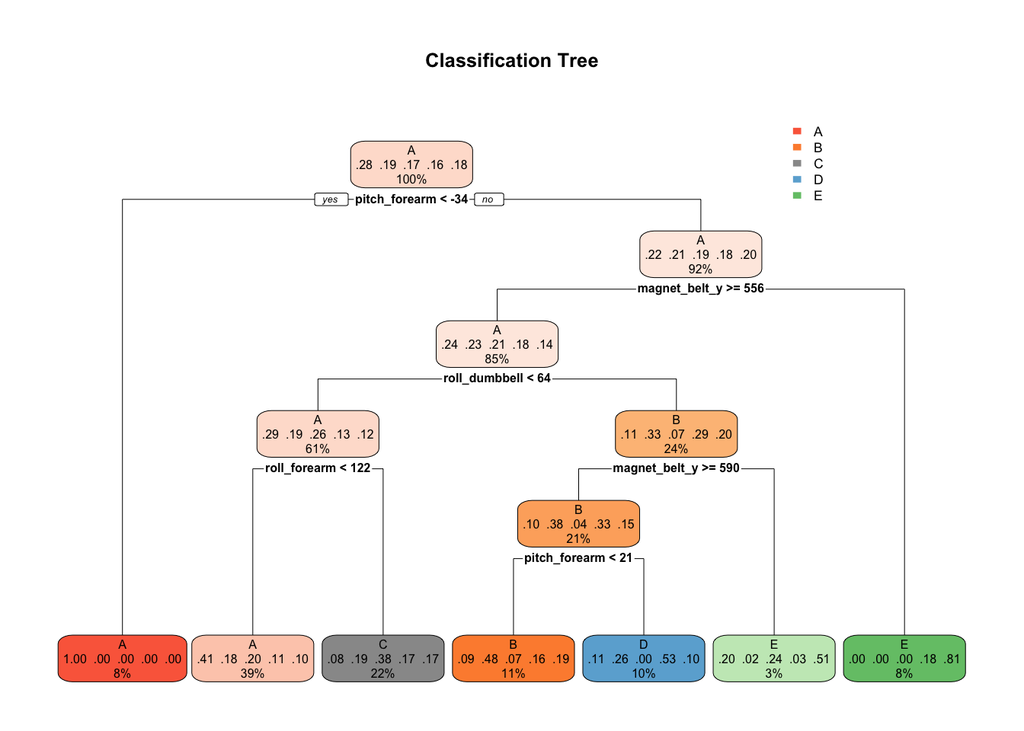

```r
rpart.plot(modCT$finalModel,main="Classification Tree")
```

```r
# Validating
predCT=predict(modCT, newdata = validating)
cMatrixCT=confusionMatrix(validating$classe,predCT)
```

#### Random Forest

```r
modRF = train(classe ~ .,data=training,method='rf', trControl = tControl,metric=metric)
print(modRF$finalModel)
```

```
##
## Call:
##  randomForest(x = x, y = y, mtry = param$mtry)
##                Type of random forest: classification
##                      Number of trees: 500
## No. of variables tried at each split: 2
##
##         OOB estimate of  error rate: 1.61%
## Confusion matrix:
##      A    B    C    D    E class.error
## A 4168   10    5    2    0 0.004062127
## B   44 2789   13    1    1 0.020716292
## C    6   45 2495   19    2 0.028048305
## D    2    4   70 2333    3 0.032752902
## E    0    2    1    7 2696 0.003695492
```

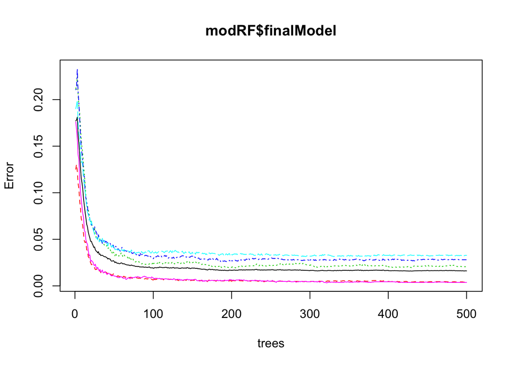

```r
plot(modRF$finalModel)
```

```r
# Validating
predRF=predict(modRF, newdata = validating)
cMatrixRF=confusionMatrix(validating$classe,predRF)
```

#### Modeling using Generalized Boosted Regression

```r
modGBM = train(classe ~ .,data=training,method="gbm", trControl=tControl, metric=metric, verbose=FALSE)
print(modGBM$finalModel)
```

```
## A gradient boosted model with multinomial loss function.
## 150 iterations were performed.
## There were 21 predictors of which 21 had non-zero influence.
```

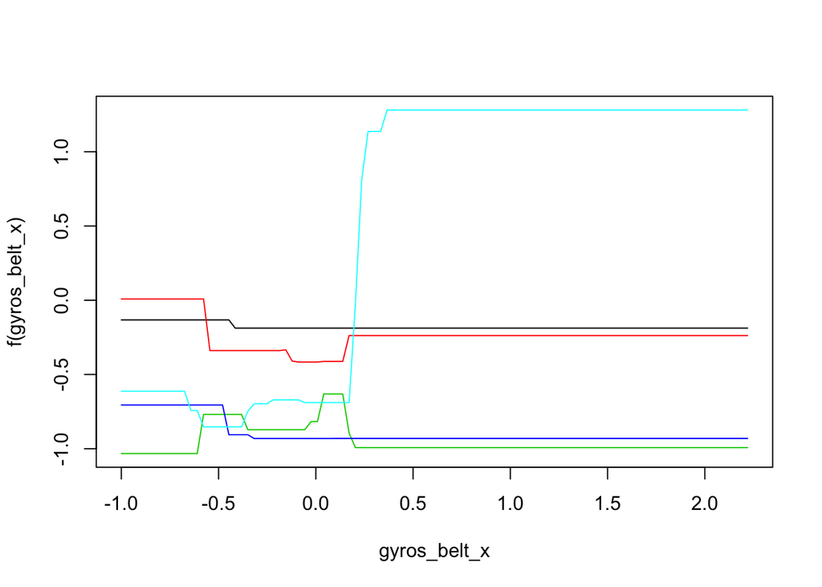

```r
plot(modGBM$finalModel)
```

```r
# Validating
predGBM=predict(modGBM, newdata = validating)
cMatrixGBM=confusionMatrix(validating$classe,predGBM)
```

#### Choosing the better model

```r
dfOverall=rbind(cMatrixCT$overall,cMatrixRF$overall,cMatrixGBM$overall)
rownames(dfOverall)=c("Classification Tree","Random Forest", "Generalized Boosted Regression")
kable(dfOverall[,1:4], caption="Summary of models's accuracy ")
```

Summary of models’s accuracy

|  | Accuracy | Kappa | AccuracyLower | AccuracyUpper |
| --- | --- | --- | --- | --- |
| Classification Tree | 0.4944943 | 0.3457864 | 0.4804059 | 0.5085892 |
| Random Forest | 0.9802202 | 0.9749730 | 0.9759230 | 0.9839314 |
| Generalized Boosted Regression | 0.8688825 | 0.8340529 | 0.8591140 | 0.8782096 |

##### Radom Forest model showed better acccuracy, let’s use this model

## Testing the model

#### Cleaning the testing dataset

```r
dim(testing)
```

```
## [1]  20 160
```

```r
trainVars=names(training)
testing=testing[ ,(names(testing) %in% trainVars)]
dim(testing)
```

```
## [1] 20 21
```

#### Predicting

```r
predTest=predict(modRF, newdata = testing)
predTest
```

```
##  [1] B A B A A E D B A A B C B A E E A B B B
## Levels: A B C D E
```